# Bayesian State Space Models in JASP

This blog article demonstrates how to use the new Bayesian state space JASP module to analyse time series data. Normally, state space models are difficult to construct, but the new module makes the powerful state space approach available with the click of a few buttons! It is based on the `bsts` package (Scott, 2020) which covers Gaussian linear state space models and deconstructs a time series into individual components, such as trends or seasonality. It also allows for Bayesian variable selection, prediction about future values, and control charts.

## Quick introduction to state space models

Most readers might not be familiar with state space models, so let us briefly introduce them. It would be beyond the scope of this blog post to explain them in full detail, so feel free to check out [this](https://kevinkotze.github.io/ts-4-state-space/) and [this](http://oliviayu.github.io/post/2019-03-21-bsts/) excellent blog posts. State space models generally assume that we have a hidden state $\alpha_t$, which changes over time and is the data generating process behind our actual observations $y_t$. And while we can’t directly observe the hidden states containing our parameters of interest, we use the observations to estimate them. Figure 1 depicts how the individual observations only depend on the corresponding state, while each state depends on its previous iteration (also known as a hidden Markov chain).

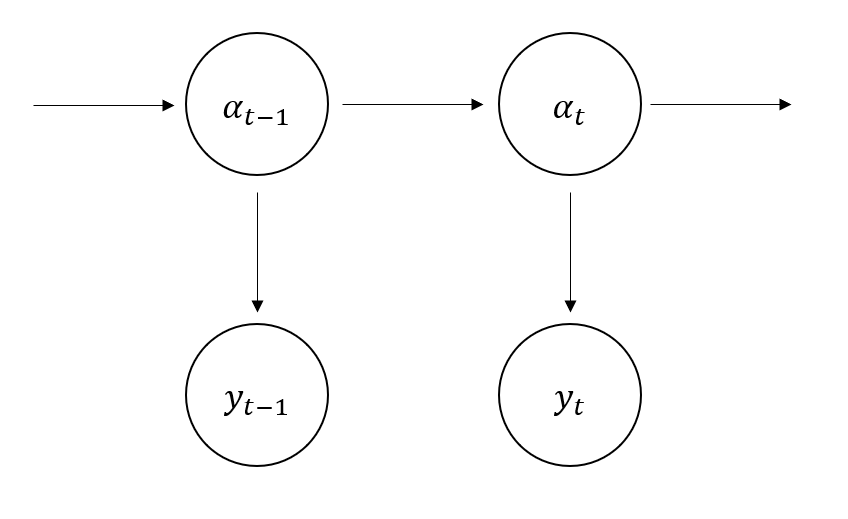

Figure 1: Illustration of dependency between state and observation

What makes state space models so flexible is that the hidden state $\alpha_t$ can contain a wide variety of parameters such as trends, seasonality or (auto)regressive components. This allows us to tweak the parameters to capture a wide variety of time series data. The model that we will use is the so called **local linear trend model**. Here the state follows a trend which is defined by its mean $\mu_t$ and a slope $\delta_t$ (i.e., $\alpha_t = \bigl( \begin{smallmatrix}\mu_t\\ \delta_t \end{smallmatrix}\bigr)$).

$$y_t = \mu_t + \epsilon_t\\
\mu_{t+1} = \mu_t + \delta_t + \eta_{\mu,t}\\
\delta_{t+1} = \delta_t + \eta_{\delta,t}$$

The first so called *observation equation* denotes that our observations $y_t$ are the result of the state or rather its trend mean plus $\epsilon_t$ where $\epsilon_t \sim \mathcal{N}(0,\sigma^2_{\epsilon})$. Furthermore, the first *state equation* denotes that the state at time point $t+1$ will be the mean of the previous state $\mu_t$ plus some downward or upward shift $\delta_t$ plus $\eta_{\mu,t}$ where $\eta_{\mu,t} \sim \mathcal{N}(0,\sigma^2_{\mu})$. Additionally, the second *state equation* denotes that the slope follows a random walk which allows it to vary slowly over time as the error term $\eta_{\delta,t} \sim \mathcal{N}(0,\sigma^2_{\delta})$ is added to the previous iteration. Since we now understand state space models a bit better, we will take a look at the JASP module and how we can select the local linear trend model (including covariates) for some example data.

## Example 1: How does negative mood vary over time and by what variables is it affected?

Kossakowski and colleagues (2017) collected a data set which is suitable for demonstrating the functionality of the bsts module: A previously depressed participant filled out an experience sampling questionnaire multiple times a day for 239 days. The questionnaire contained items about current mood but also qualitative questions regarding activity and social contact.

We will use the *bsts* module to demonstrate how we can answer the question “Does the negative mood follow a trend?” and “Which variables predict negative mood the best?” We achieve this by decomposing the negative mood of the participant into a time-varying trend, as well as a regression component. To do so, we simply extend the equations above by adding the regression component $\beta x_t$ to the observation equation:

$$y_t = \mu_t + \beta x_t + \epsilon_t\\
\mu_{t+1} = \mu_t + \delta_t + \eta_{\mu,t}\\
\delta_{t+1} = \delta_t + \eta_{\delta,t}$$

$$\gamma \sim \prod \pi_i^{\gamma_i} (1-\pi_k)^{1-\gamma_i}.$$

Here $\pi_i$ reflects the probability that a particular $y_i =1$. This allows us to give more weight to predictors that seem promising or have been found to be impactful previously as a higher inclusion probability makes them more likely to be selected. However, when no specific prior information about the inclusion of certain predictors is available, it is common to set $\pi=p/K$. Here $p$ reflects the average number of predictors we expect to be included in the model and $K$ the number of total predictors possible. Setting the prior this way is the only option for now.

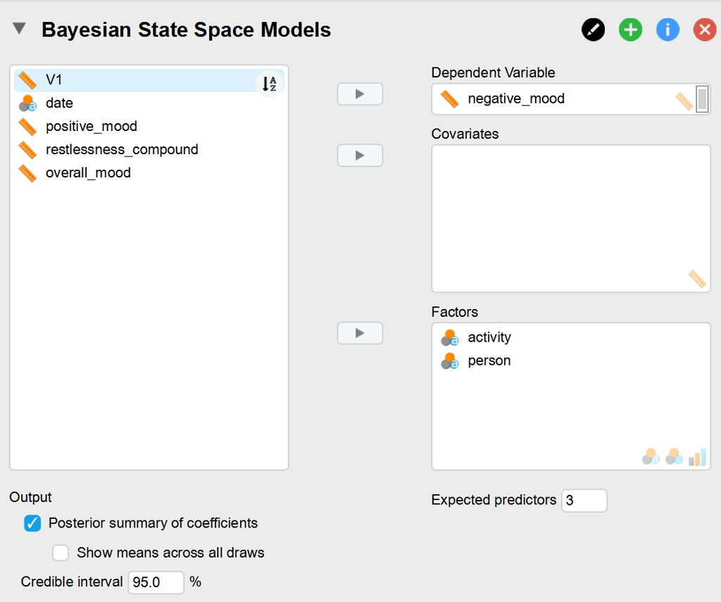

Figure 2: Selection of dependent variables, predictors and expected model size

As a next step, we select the “Posterior summary of coefficients” check box as we want JASP to display an output table containing the marginal posterior summary of the coefficients, which also includes the inclusion probability and the Bayes Factor.

Another important step is to adjust the “Expected predictors” option. As we don’t have any prior knowledge of which specific predictors are likely to be included in the model, we use the aforementioned approach: Since we expect around 3 predictors out of 16 (plus intercept) to be included in the model, the prior inclusion probability for each predictor is $\pi_k= 3/17=0.176$. After having observed the data, this prior information is updated to the posterior which tells us which predictors are most likely to be included across all possible models.

Now that we have specified our dependent variable and our regression component, we only need to specify the local linear trend of our state space model. In Figure 3 you can see the various components we could add to the model, but for our intended model, we only have to click the button “Add local linear trend component.” Note that inference of the model can be very slow depending on the number of samples of the MCMC algorithm (2000 by default) and how long the time series is.

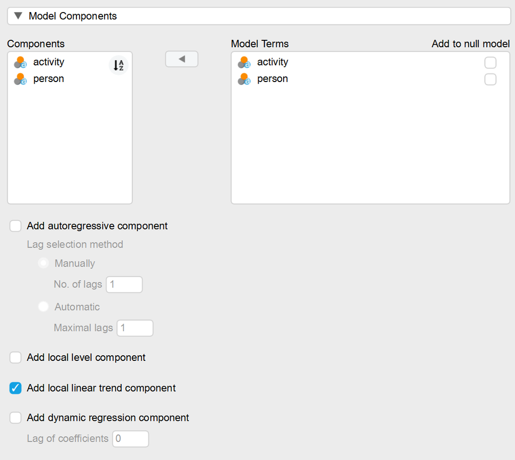

Figure 3: Selection of state space components in JASP module

Now let’s take a look at the results. The first table we can see gives us information about the general fit of the model. The residual standard deviation $\sigma^2 _\epsilon$ answers the question of how well each state captures the corresponding observation. The prediction standard deviation answers the question of how well each estimated state predicts next observation given the data until t-1 and thus can be used to asses the predictive accuracy of the model:

$$e=y_t-a_{t|t-1}$$
The $R^2$ on the other hand tells us that around 50 percent of the variance in negative mood is explained by our local linear trend plus the regression component. The Harvey’s goodness of fit is similar to $R^2$ but adjusts for the fact that trending/non-stationary time series (i.e. do not have a constant mean and variance) can inflate the normal $R^2$ measure (for mathematical details see Harvey, 1990, p. 268).

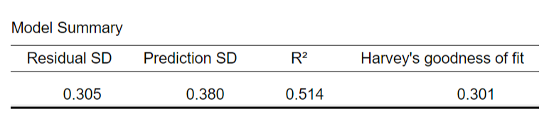

Table 1: General summary table of state space model

As mentioned before the package allows us to integrate our prior knowledge regarding the number of predictors and updates the probability of them being included in the model after having seen the data. Table 2 tells us the results of this updating process.

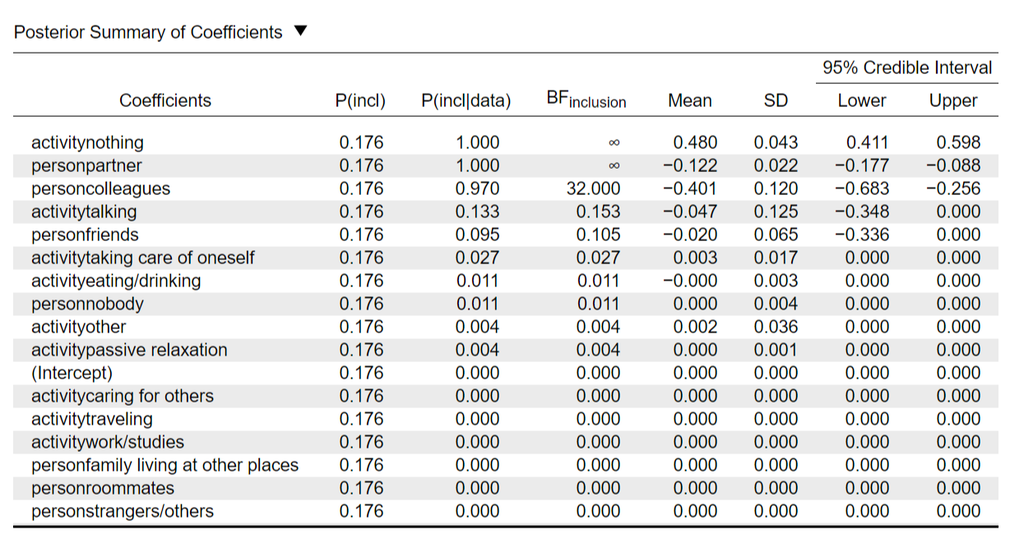

Table 2: Posterior summary of coefficients.

As we can see the prior inclusion probability *P(incl)* directly relates to the expected model size of 3 we set earlier. The next column *P(incl|data)* gives us the posterior inclusion probability or in other words the updated inclusion probability after having seen the data. So what exactly does this column tell us?

This is also reflected by the Bayes factors for inclusion which quantifies by which factor the odds of including a specific predictor have increased and is often used to measure the strength of evidence in Bayesian inference. It is calculated by diving the inclusion probability of a predictor by the exclusion probability:

$$BF_{inclusion} = \frac{P(incl|data)}{1-P(incl|data)}$$
For *doing nothing* and *being with the partner*, the Bayes factor of infinity tells us that we have incredibly strong evidence in favor of including these two predictors in the model. The inclusion probability for *being with colleagues* is 0.97 so we can divide it by the exlusion probability of (1-0.97) and arrive at a BF<sub>inclusion</sub> of 32.

On the other hand, the odds of including any other predictors have decreased: For example the odds of including talking with others has decreased by a factor of 1/0.153 = 6.5.

On a side note, it is important to not note that the choice of our prior aka the expected model size does not matter too much if we have strong evidence. For example, if we would have set the expected model size to 2 or possibly 5, the number of predictors would stay the same as the posterior will be similar since the data provided so much evidence.

But how large are the coefficients? This is indicated by the *Mean* column which gives us the posterior means for each coefficient. It tells us that doing nothing **increases** the negative mood of the patient by 0.48 points on average, while being with the partner or collegues **decreases** it by 0.122 and 0.401 points respectively.

The plot shows us that the trend stays between 2 and 2.5 most of the time but does not rise or fall strongly. Rather the variance of the variable stays relatively small for the first 500 time points and becomes larger afterwards, which is reflected by the more extreme up and down jumps in the trend.

On the lower half of the plot we see the contribution of the regression component $\beta x_t$ visualised. For example, at the time point 123 the participant does nothing and is with his partner. If we take the values for the coefficients $\beta_{nothing}$ and $\beta_{partner}$ we arrive at a regression contribution of $\beta*x_{100} = - 0.122+0.48 =0.358$. This indicates that at $t = 123$ the regression component of the state space model is responsible for an increase of 0.358 points in negative mood.

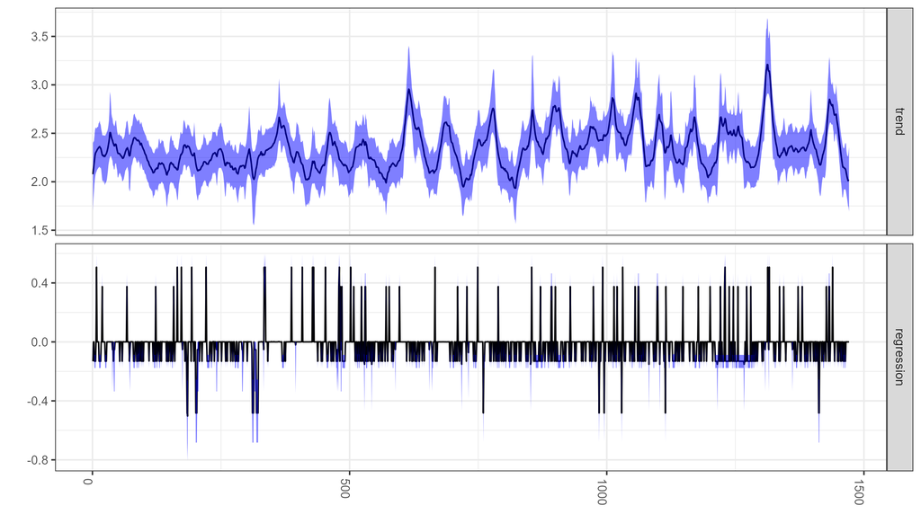

Figure 4: Visualisation of each state space component over time: Top panel displays the trend component and bottom panel displays the regression component.

The final plot to investigate is the one that combines the trend component with the regressive component. It can be activated by clicking the “Aggregated state contribution” box. The values shown in this plot are simply the sum of both state components as the trend now has the up and down jumps from the regression plot we could see in the previous plot. For example at time point 123 we have the aforementioned of 0.358 and a trend contribution of 2.1. Thus the estimated aggregated state will be:

$$\alpha_{123} = \mu_{123} +\beta*x_{123} = 2.1 + 0.358 = 2.458$$

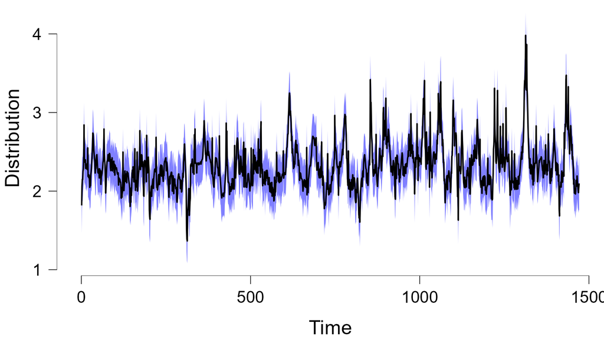

Figure 5: Visualisation of aggregated state over time. Black line depicts the state mean across MCMC draws and the blue area the 95 % credible interval.

## Example 2: Can we detect early warning signs of a depression relapse?

Another interesting application to this data set is the possible detection of early warning signs for a depression relapse as the patient eventually relapsed into depression. Smit and colleagues (2019) discovered that restlessness increased substantially more than two months prior to depression relapse in two patients. They applied an exponentially weighted moving average (EWMA) model to the data and calculated this critical threshold based on the baseline where the patient was still under antidepressant medication (first 100 time points).

However, the EWMA model uses simple cut-off values for whether or not restlessness exceeds a threshold. And while we could use the confidence intervals of the model they would only be able to tell us with which frequency the intervals would contain the true parameter if we resalmple the data again and again (e.g. 95 percent of the time). Especially since the data is impossible to collect again, we are much more interested in how likely it is that the true value exceeds our threshold. Using the Bayesian state space model, we are able to quantify our uncertainty about whether the data exceeded the threshold in probabilistic terms.

As a first step, we calculate the mean for each day of the data set. This is necessary because the Bayesian state space model (as well as the EWMA model) assumes our observations to be normally distributed and the raw data is not. The resulting histogram can be found in Figure 6.

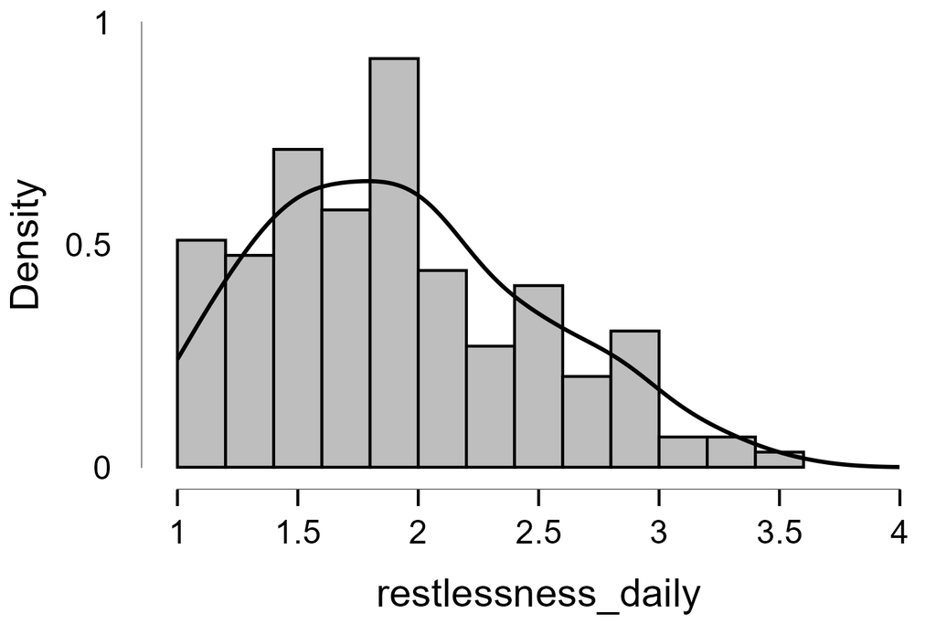

Figure 6: Histogram of restlessness averaged on a daily basis

We then apply a state space model with only a local linear trend component (as discussed in the beginning of the blog post). As we use daily data and the raw first 100 time points span over 17 days, we will use the first 17 averaged daily time points to calculate the baseline. We take the mean of the first 17 state estimates and then add and subtract two standard deviations: $Threshold = \mu_{\alpha_{1:17}} \pm 2*\sigma_{1:17}$. We use the estimated hidden state instead of the actual observation to calculate the threshold as the state space model estimates the **true** hidden state from our noisy observations. In JASP, we can select this option via the “Show control chart” option under “Plots,” setting the “Control period end” to 17 and activating the “Show probabilistic control plot” option.

Looking at the aggregated state in Figure 7 we can clearly seethat compared to negative mood in our first example, the trend of restlessness increases over time. The two red dotted lines are the two critical thresholds and whenever the blue shaded area exceeds the red line, whether our threshold is exceeded. The note at the bottom tells us that the first time restlessness exceeds the threshold is on the 28th of September. This is more than two months before the patient relapsed into depression (mid of December) and coincides with the results by Smit and colleagues.

It is very important to note that the selection of a threshold is arbitrary and thus needs to be theoretically grounded: Depending on how many standard deviation we use to construct the threshold that indicates a substantial increase in a variable, we can easily generate false positive results if we make that choice after having obtained the data. Furthermore, restlessness was the only variable of multiple to be identified retrospectively as a warning sign without there being a lot of evidence in the existing literature that supports this. Thus in order to conclude that increasing restlessness could truly function as an early warning sign and avoid generating false positive results, planned replications are needed that decide on a variable and threshold before data collection.

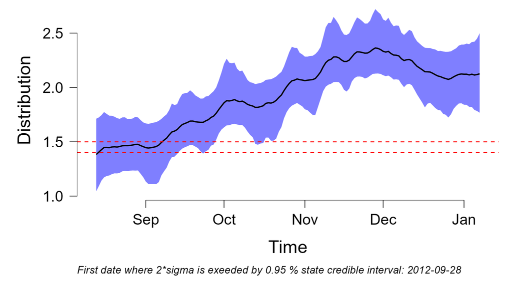

Figure 7: Critical threshold on top of state estimation. The black line depicts the state mean and the blue area the credible interval. The red-dotted line indicates the critical threshold.

## References

Harvey, A. C. (1990). *Forecasting, structural time series models and the kalman filter* (1st ed.). Cambridge University Press. https://doi.org/10.1017/CBO9781107049994

Kossakowski, J. J., Groot, P. C., Haslbeck, J. M. B., Borsboom, D., & Wichers, M. (2017). Data from ‘Critical Slowing Down as a Personalized Early Warning Signal for Depression’. *Journal of Open Psychology Data*, *5*, 1. https://doi.org/10.5334/jopd.29

Scott, S. L. (2020). *Bsts: Bayesian structural time series*. https://CRAN.R-project.org/package=bsts

Smit, Arnout C., Snippe, E., & Wichers, M. (2019). Increasing Restlessness Signals Impending Increase in Depressive Symptoms More than 2 Months before It Happens in Individual Patients. *Psychotherapy and Psychosomatics*, *88*(4), 249–251. https://doi.org/10.1159/000500594